# Solucionario: Recuperatorio (30pts)

Programacion Estadística I

Lic. Alvaro Chirino Gutierrez

Julio, 2020

# Pregunta 1 (15 puntos)

Usando la información de www.worldometers.com sobre el COVID con la librería rvest, para los datos mas actuales, generar en un documento R markdown:

- Tabla de países por continente (separadas o juntas)
  - Top 5 casos por millón
  - Top 5 test por millón

```r
rm(list=ls())
library(rvest)
library(dplyr)
covid<-read_html("https://www.worldometers.info/coronavirus/")
aux<-html_table(covid)
t<-aux[[1]]
names(t)[1]<-"id"
t<-t[!is.na(t$id),]
names(t)[11]<-"casoM"
names(t)[14]<-"testM"
names(t)[12]<-"muerteM"
names(t)[7]<-"recup"

t$casoM<-as.numeric(gsub(",","",t$casoM))
t$testM<-as.numeric(gsub(",","",t$testM))
t$muerteM<-as.numeric(gsub(",","",t$muerteM))
t$recup<-as.numeric(gsub(",","",t$recup))
t <- t %>% filter(16 !="")
#casos
tt1<-t %>% mutate(nn=1) %>% arrange(desc(casoM)) %>% group_by(Continent)  %>% mutate(nn=cumsum(nn)) %>% filter(nn<=5) %>% select(`Country,Other`,casoM,nn)
tt1<-tt1 %>% arrange(Continent)
knitr::kable(tt1,caption = "Top 5 casos por Millon por país y continente")
```

Top 5 casos por Millon por país y continente

| Continent | Country,Other | casoM | nn |
| --- | --- | --- | --- |
|  | Diamond Princess | NA | 1 |
|  | MS Zaandam | NA | 2 |
| Africa | Mayotte | 10477 | 1 |
| Africa | South Africa | 6875 | 2 |
| Africa | Djibouti | 5088 | 3 |
| Africa | Cabo Verde | 3936 | 4 |
| Africa | Sao Tome and Principe | 3414 | 5 |
| Asia | Qatar | 38551 | 1 |
| Asia | Bahrain | 22293 | 2 |
| Asia | Kuwait | 14476 | 3 |
| Asia | Oman | 14207 | 4 |
| Asia | Armenia | 12202 | 5 |
| Australia/Oceania | Australia | 521 | 1 |
| Australia/Oceania | New Zealand | 311 | 2 |
| Australia/Oceania | French Polynesia | 221 | 3 |
| Australia/Oceania | New Caledonia | 77 | 4 |
| Australia/Oceania | Fiji | 30 | 5 |
| Europe | San Marino | 20598 | 1 |
| Europe | Vatican City | 14981 | 2 |
| Europe | Andorra | 11505 | 3 |
| Europe | Luxembourg | 9499 | 4 |
| Europe | Sweden | 7796 | 5 |
| North America | Panama | 13156 | 1 |
| North America | USA | 12593 | 2 |
| North America | Dominican Republic | 5308 | 3 |
| North America | Honduras | 3642 | 4 |
| North America | Cayman Islands | 3087 | 5 |
| South America | French Guiana | 23692 | 1 |
| South America | Chile | 17712 | 2 |
| South America | Peru | 11246 | 3 |
| South America | Brazil | 10768 | 4 |
| South America | Bolivia | 5490 | 5 |

```r
#test
tt2<-t %>% mutate(nn=1) %>% arrange(desc(testM)) %>% group_by(Continent)  %>% mutate(nn=cumsum(nn)) %>% filter(nn<=5) %>% select(`Country,Other`,testM,nn)
tt2<-tt2 %>% arrange(Continent)
knitr::kable(tt2,caption = "Top 5 test por Millon por país y continente")
```

Top 5 test por Millon por país y continente

| Continent | Country,Other | testM | nn |
| --- | --- | --- | --- |
|  | Diamond Princess | NA | 1 |
|  | MS Zaandam | NA | 2 |
| Africa | Mauritius | 161400 | 1 |
| Africa | Cabo Verde | 74834 | 2 |
| Africa | Djibouti | 56067 | 3 |
| Africa | Mayotte | 47590 | 4 |
| Africa | South Africa | 44347 | 5 |
| Asia | UAE | 472575 | 1 |
| Asia | Bahrain | 446337 | 2 |
| Asia | Singapore | 199900 | 3 |
| Asia | Israel | 166918 | 4 |
| Asia | Qatar | 162332 | 5 |
| Australia/Oceania | Australia | 145408 | 1 |
| Australia/Oceania | New Zealand | 89720 | 2 |
| Australia/Oceania | New Caledonia | 34694 | 3 |
| Australia/Oceania | French Polynesia | 16544 | 4 |
| Australia/Oceania | Fiji | 4460 | 5 |
| Europe | Monaco | 973255 | 1 |
| Europe | Faeroe Islands | 627294 | 2 |
| Europe | Luxembourg | 598913 | 3 |
| Europe | Gibraltar | 550134 | 4 |
| Europe | Iceland | 348886 | 5 |
| North America | Cayman Islands | 438496 | 1 |
| North America | Bermuda | 288422 | 2 |
| North America | USA | 155688 | 3 |
| North America | Greenland | 99426 | 4 |
| North America | Canada | 97910 | 5 |
| South America | Falkland Islands | 521090 | 1 |
| South America | French Guiana | 116350 | 2 |
| South America | Chile | 76578 | 3 |
| South America | Peru | 65420 | 4 |
| South America | Venezuela | 51729 | 5 |

- Gráficos de países por continente (incluir en el gráfico los nombres de los países.)
  - Casos por millón vs Test por millón
  - Muertes por millón vs logaritmo de los recuperados

[figure not shown]

```r
library(ggplot2)
#Casos por millón vs Test por millón
ggplot(t,aes(casoM,testM,label=`Country,Other`))+geom_text(size=2)+facet_wrap(~Continent)
```

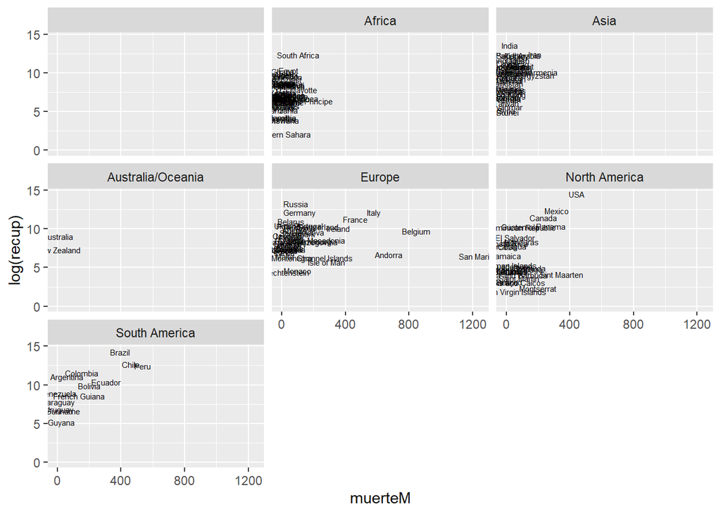

```r
#Muertes por millón vs logaritmo de los recuperados
ggplot(t,aes(muerteM,log(recup),label=`Country,Other`))+geom_text(size=2)+facet_wrap(~Continent)
```

# Pregunta 2 (15 puntos)

Realice una función en Shiny empleando la base de datos para la ENDSA que permita ver por departamento y año:

- Tabla que muestre la relación entre sexo y años de educación
- Gráfico que muestre la relación entre “edad a la primera relación sexual” vs “Total de niños nacidos”

# Pregunta 1 (15 puntos)

Usando la encuesta de hogares 2018 defina una base de datos que contenga las siguientes variables para jefes de hogar mujeres:

- Edad
- Ingreso laboral
- Ingreso no laboral
- Ingreso personal
- Departamento
- Años de educación
- Área
- Tipo de hogar
- Número de miembros en el hogar
- Personas de 5 años o menos en el hogar
- Personas de 60 años o más en el hogar
- Hogar con electricidad
- Acceso a internet en el hogar
- Piso de tierra en la vivienda

(Sugerencia: Use la variable folio y el comando merge para unir bases, para identificar algunas variables se recomienda usar el cuestionario en pdf)

# Pregunta 2 (15 puntos)

Para la base alojada en R y la base alojada en Spark (del ejercicio anterior), genere lo siguiente:

- Promedio de años de educación e ingreso personal por departamento, área y acceso a internet
- Proporción de jefas del hogar con un ingreso personal superior a 3000 Bs. Por departamento y tipo de hogar
- Promedio de personas de 5 años o menos y personas de 60 años o más, por tipo de hogar, área y piso de tierra.
- Gráfico sobre el acceso al internet por tipo de hogar (ggplot)